# Analyzing Breaks in Yarn by Tension

```r
#* See http://yihui.name/knitr/options/ for
#* a list of all chunk options.

library(dplyr)
```

```r
library(broom)
library(pixiedust)
library(ggplot2)
```

# Purpose

# The `warpbreaks` data

The `warpbreaks` dataset, available in the `datasets` package, is a data frame with 54 rows and 3 columns. There are 2 levels of the `wool` variable and 3 levels of the `tension` variable, with 9 observations at each combination.

*From this point on, we’ll assume we’re performing the analysis as if we didn’t know there was more data coming later.*

# Exploratory Data Analysis

The data were gathered in a balanced design with 9 observations per `wool-tension` group. A total of 54 observations were made. A summary of the number of breaks in each group is provided in the table below.

| Wool | Tension | Mean | SD | Min | P25 | Median | P75 | Max |
| --- | --- | --- | --- | --- | --- | --- | --- | --- |
| A | L | 44.56 | 18.1 | 25 | 26 | 51 | 54 | 70 |
| A | M | 24 | 8.66 | 12 | 18 | 21 | 30 | 36 |
| A | H | 24.56 | 10.27 | 10 | 18 | 24 | 28 | 43 |
| B | L | 28.22 | 9.86 | 14 | 20 | 29 | 31 | 44 |
| B | M | 28.78 | 9.43 | 16 | 21 | 28 | 39 | 42 |
| B | H | 18.78 | 4.89 | 13 | 15 | 17 | 21 | 28 |

And a few plots for the number of breaks by group

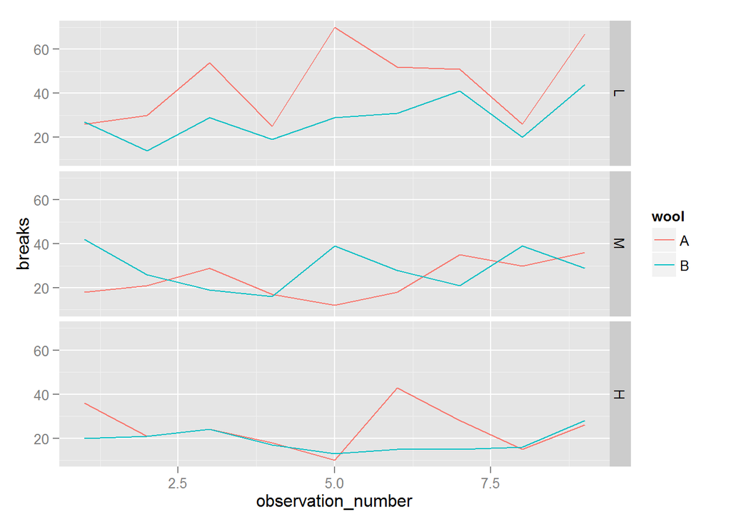

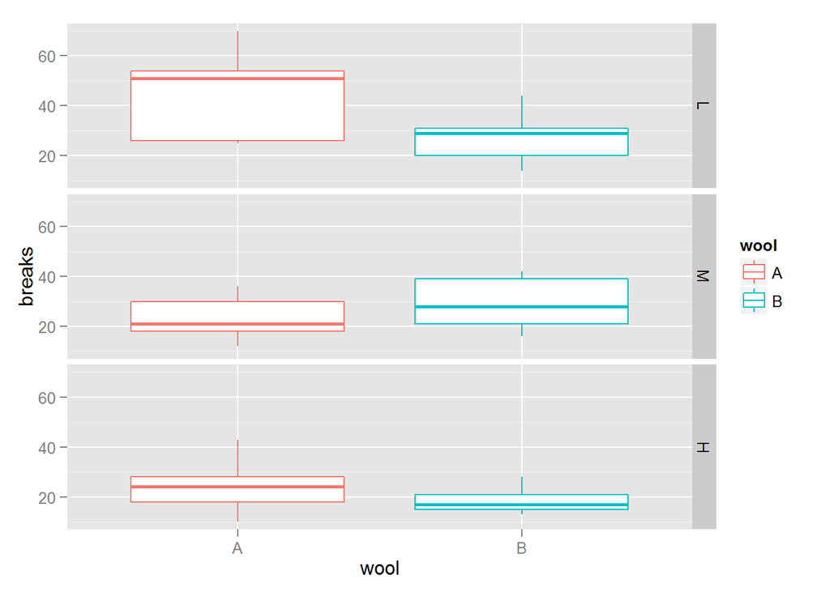

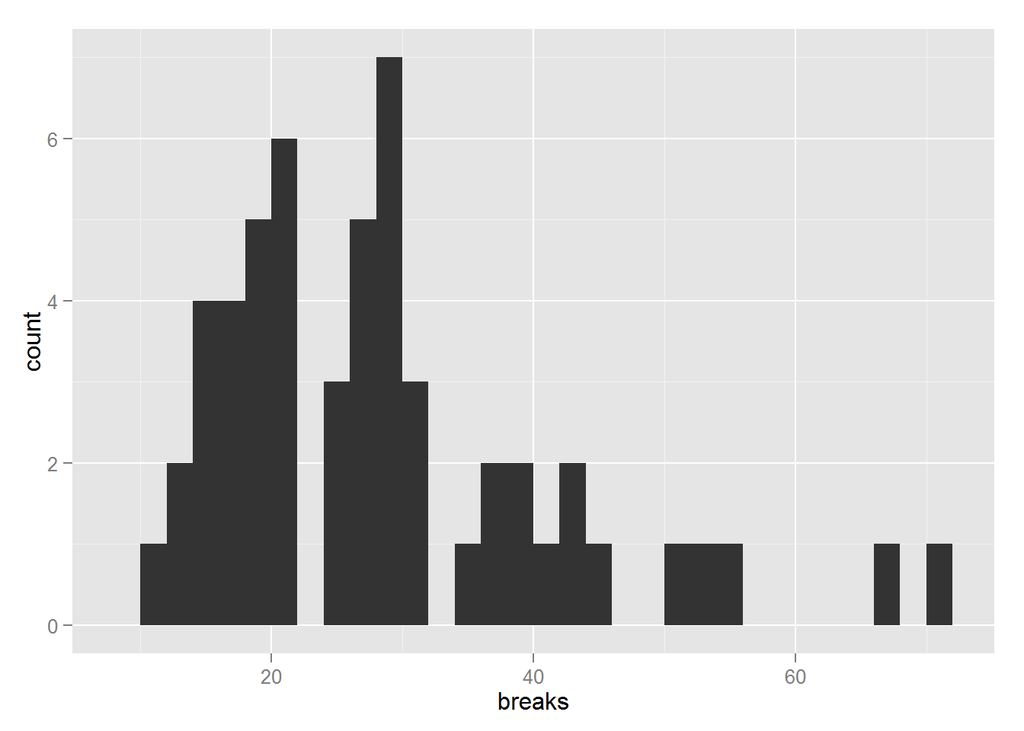

# Analysis

To evaluate the effect of wool and tension on the number of breaks observed, we perform an analysis of variance to see if there are differences between groups.

```r
fit <- aov(breaks ~ wool + tension, data = Breaks)
```

| Term | DF | SS | MS | F | P-value |
| --- | --- | --- | --- | --- | --- |
| wool | 1 | 450.67 | 450.67 | 3.34 | 0.074 |
| tension | 2 | 2034.26 | 1017.13 | 7.54 | 0.001 |
| Residuals | 50 | 6747.89 | 134.96 |  |  |

```r
#* Check the model diagnostics
par(mfrow=c(2, 2))
plot(fit)
```

[output not shown]

An ordinary least squares / linear regression model provides us with estimates of the change in breaks between levels of the tension variable.

```r
lm_result <- tidy(lm(fit))
```

| Term | Level | Estimate | Std. Error | T | P-value |
| --- | --- | --- | --- | --- | --- |
| breaks |  | 39.28 | 3.16 | 12.42 | < 0.001 |
| wool | B vs. A | -5.78 | 3.16 | -1.83 | 0.074 |
| tension | M vs. L | -10 | 3.87 | -2.58 | 0.013 |
| tension | H vs. L | -14.72 | 3.87 | -3.8 | < 0.001 |
| adj.r.squared | 0.23 |  |  | AIC | 423.96 |
| df | 4 |  |  |  |  |

# Conclusions

Based on the results of the analysis of variance, we find insufficient evidence to claim that wool is associated with a difference in yarn breaks (p = 0.07). A statistically significant association between tension and yarn breaks was observed (p = 0.001). The results of the linear regression suggest that breaks decrease as tension incrases.